# second week: Introduction to R and Rstudio

Mobile Data

Erfan Hosseini_93101373

2018-02-19 16:32:20

# تمرین سری دوم: تلفن همراه شناسی!

> با استفاده از داده های گوشی های همراه به سوالات زیر پاسخ دهید. برای رسم نمودار از پکیج ggplot2 استفاده کنید.

۱. کدام شرکت بیشترین تعداد گوشی را تولید کرده است؟ نمودار ستونی ۲۰ شرکت برتر بر حسب تعداد گوشی تولید کرده را رسم کنید.

```r
#path to mobile data
path = '~/R/HW2/hw_02/mobile_data.csv'
library(readr)
library(ggplot2)
library(dplyr)
library(ggthemes)
mobile = read_csv(path)
mobile %>% group_by(company) %>% summarise(count = n()) %>% arrange(desc(count)) -> compCount
topComp = compCount[1:20,1:2]
print(topComp[1,1])
```

```
## # A tibble: 1 x 1
##   company
##   <chr>
## 1 Samsung
```

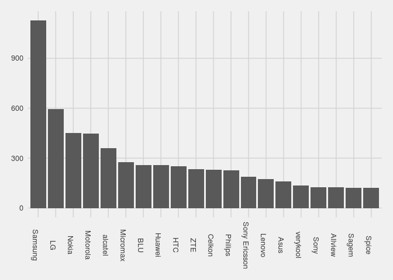

```r
topComp$company <- factor(topComp$company, levels = topComp$company)
p = ggplot(data = topComp, aes(x = company, y = count)) + theme_fivethirtyeight()
p + geom_bar(stat = 'identity') + theme(axis.text.x = element_text(angle = 270))
```

۲. نمودار زمانی طول عرض ضخامت و کیفیت دوربین گوشی ها را بکشید و به نمودار هر یک مدل خطی اضافه کنید.

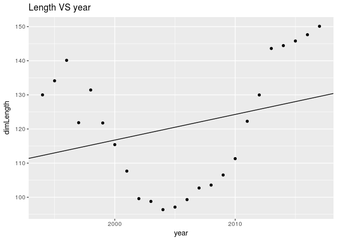

```r
# tul
mobile %>% group_by(year) %>% summarise(dimLength = mean(dim_length, na.rm = T)) %>% na.omit() -> len
p = ggplot(data = len, aes(x = year, y= dimLength))
coef = coef(lm(dimLength ~ year, data = len))
p + geom_point() + geom_abline(intercept = coef[1], slope=coef[2]) + ggtitle('Length VS year')
```

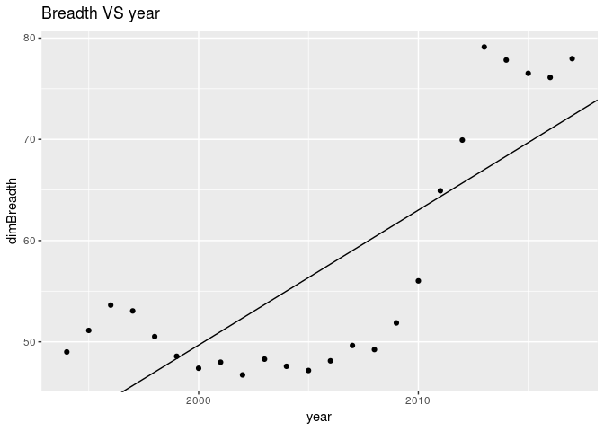

```r
# arz
mobile %>% group_by(year) %>% summarise(dimBreadth = mean(dim_breadth, na.rm = T)) %>% na.omit() -> breadth
p = ggplot(data = breadth, aes(x = year, y= dimBreadth))
coef = coef(lm(dimBreadth ~ year, data = breadth))
p + geom_point() + geom_abline(intercept = coef[1], slope=coef[2]) + ggtitle('Breadth VS year')
```

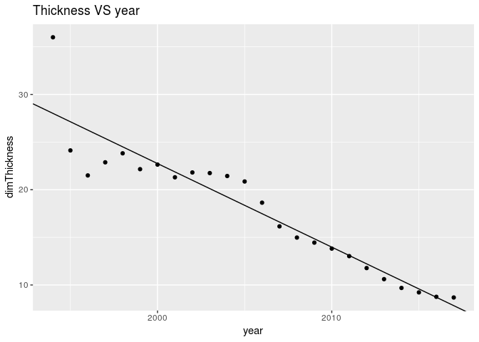

```r
# zekhamat
mobile %>% group_by(year) %>% summarise(dimThickness = mean(dim_thickness, na.rm = T)) %>% na.omit() -> thickness
p = ggplot(data = thickness, aes(x = year, y= dimThickness))
coef = coef(lm(dimThickness ~ year, data = thickness))
p + geom_point() + geom_abline(intercept = coef[1], slope=coef[2]) + ggtitle('Thickness VS year')
```

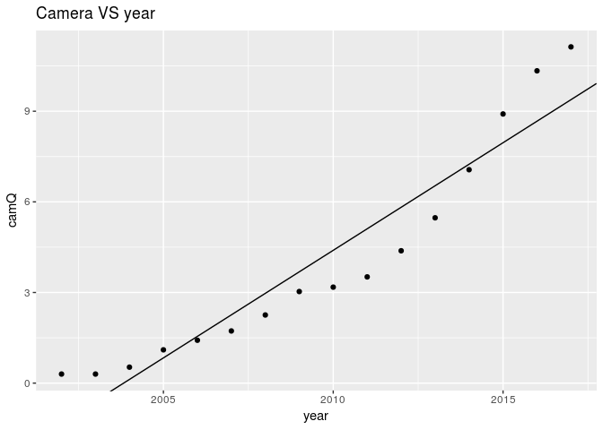

```r
# keyfiyate durbin
mobile %>% group_by(year) %>% summarise(camQ = mean(cam_px, na.rm = T)) %>% na.omit() -> camQual
p = ggplot(data = camQual, aes(x = year, y= camQ))
coef = coef(lm(camQ ~ year, data = camQual))
p + geom_point() + geom_abline(intercept = coef[1], slope=coef[2]) + ggtitle('Camera VS year')
```

۳. نمودار ستونی متوسط قیمت گوشی بر حسب تعداد سیم کارت و دسترسی به LTE را رسم نمایید.

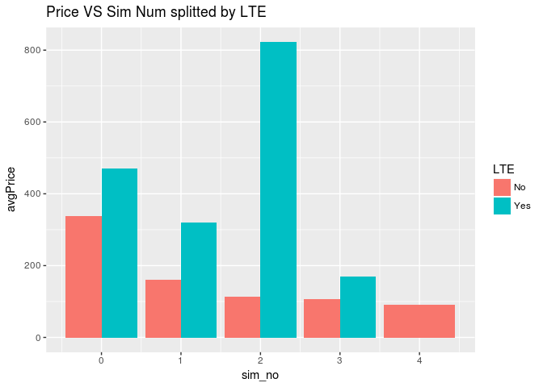

```r
# part 3
mobile %>% group_by(sim_no,LTE) %>%  summarise(avgPrice = mean(price, na.rm = T)) -> res
p = ggplot(data = res, aes(x=sim_no, y = avgPrice))
p + geom_bar(aes(fill=LTE), stat = 'identity', position = 'dodge') + ggtitle('Price VS Sim Num splitted by LTE')
```

۴. نمودار جعبه ایی ضحامت گوشی هایی که در سال ۲۰۱۷ معرفی شده اند را برحسب اینکه کمیت جک هدفون رسم نمایید

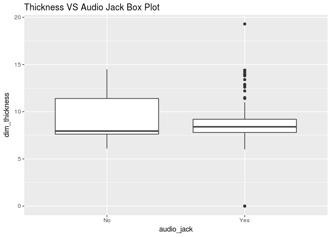

```r
# part 4
mod = mobile[which(mobile$year == 2017),]
mod = mod[,c('dim_thickness','audio_jack')] %>% na.omit()
p = ggplot(data = mod, aes(x = audio_jack, y = dim_thickness))
p + geom_boxplot() + ggtitle('Thickness VS Audio Jack Box Plot')
```

۵. مفهوم ppi را در گوشی های موبایل محاسبه و هیستوگرام آن را رسم نمایید. همچنین نمودار سالانه متوسط این کمیت را بکشید. کدام گوشی بیشترین ppi را دارد؟

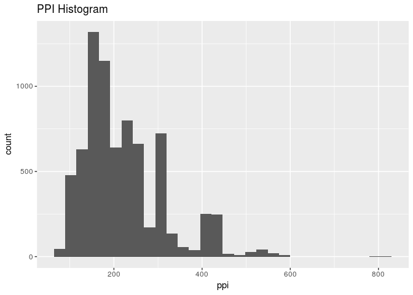

```r
# part 5
mod = mobile[,c('device','year','display_size','px_col','px_row')] %>% na.omit()
mod$ppi = sqrt((mod$px_col ^2 + mod$px_row ^2) / mod$display_size ^ 2)
p = ggplot(data = mod, aes(x = ppi))
p + geom_histogram() + ggtitle('PPI Histogram')
```

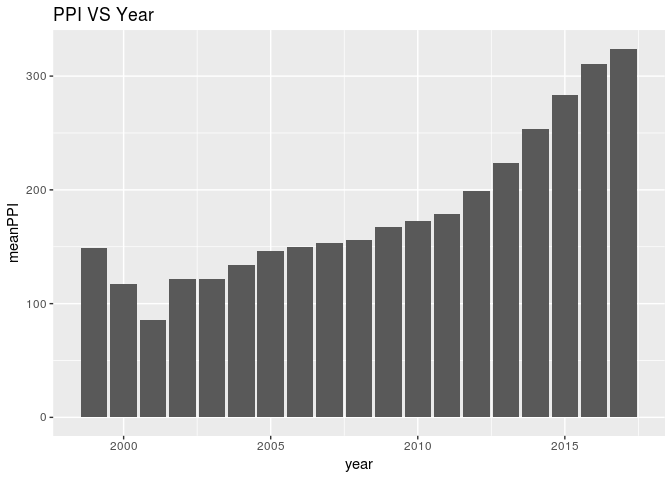

```r
mod %>% group_by(year) %>% summarise(meanPPI = mean(ppi)) -> meanPPIRep
p = ggplot(data = meanPPIRep, aes(x = year, y = meanPPI))
p + geom_bar(stat = 'identity') + ggtitle('PPI VS Year')
```

```r
max = mod[which.max(mod$ppi),]
# Device with maximum PPI
print(max$device)
```

```
## [1] "Xperia XZ Premium"
```

۶. در گذشته به بعضی از مدل های گوشی نوکیا **گوشکوب** گفته می شد. سعی کنید برای این مفهوم کمیتی مناسب تعریف کنید . ده گوشکوب برتر را پیدا کرده و نمودار گوشکوبیت آن را رسم نمایید.

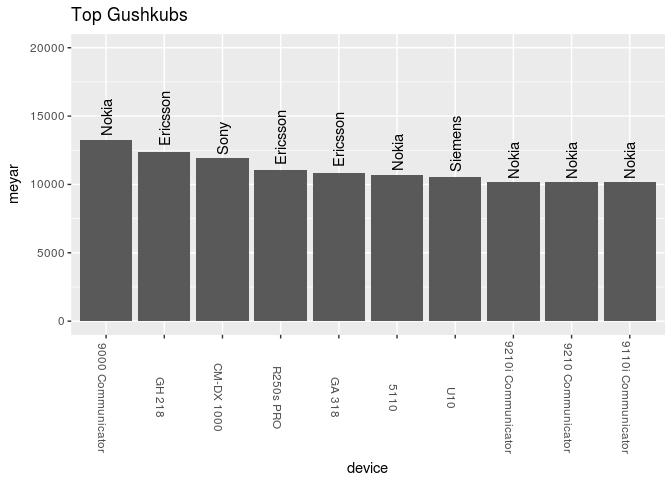

[figure not shown]

```r
mod = mobile[c('device','company', 'dim_length','dim_thickness','dim_breadth')] %>% na.omit()
mod = mod[which(mod$dim_breadth < 100 & mod$dim_thickness < 40),]
mod$ratio = mod$dim_breadth / mod$dim_thickness
mod$meyar = 1000/abs(1-(mod$dim_breadth/mod$dim_thickness)) + mod$dim_length*30 + mod$dim_breadth*mod$dim_thickness + mod$dim_thickness * 110
mod %>% arrange(desc(meyar)) -> mod
mod %>% head(10) -> mod
mod$device <- factor(mod$device, levels = mod$device)
p = ggplot(data = mod, aes(x = device, y = meyar))
p + geom_bar(stat = 'identity') + geom_text(aes(label = company), angle = 90, hjust = -0.1)+ scale_y_continuous(limits = c(0,20000)) + ggtitle('Top Gushkubs') + theme(axis.text.x = element_text(angle = 270))
```

Nokia 9000 Communicator

[figure not shown]

Ericsson GH218

[figure not shown]

Sony CM-DX 1000

[figure not shown]

Ericsson R250s

۷. آیا تلفن همراهی وجود دارد که در آب غرق نشود؟ اگر جواب بله هست تمام گوشی های که این خاصیت را دارند بیابید. با کشیدن یک نمودار به این سوال پاسخ دهید.

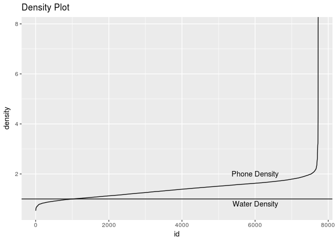

```r
mod = mobile[c('device','dim_length','dim_thickness','dim_breadth','weight')] %>% na.omit()
mod$density = mod$weight/(mod$dim_length * mod$dim_breadth * mod$dim_thickness/1000)
mod %>% arrange(density) -> mod
mod$id = seq.int(nrow(mod))
p = ggplot(data = mod, aes(x= id, y = density))
p + geom_line()  + geom_abline(intercept = 1, slope = 0) + ggtitle('Density Plot') + annotate("text", x=6000, y=2,label = 'Phone Density') + annotate("text", x=6000, y=0.8,label = 'Water Density')
```

```r
sel = mod[which(mod$density<1 ),]
print(sel$device)
```

```
##    [1] "J520"                   "Xelibri 6"
##    [3] "G82"                    "Xelibri 8"
##    [5] "Mouse"                  "Slick"
##    [7] "G70"                    "Trium Sirius"
##    [9] "Whiz"                   "cd930"
##   [11] "cd920"                  "Trium Eclipse"
##   [13] "Lindy"                  "C155"
##   [15] "CMD C1"                 "Xelibri 2"
##   [17] "Xelibri 7"              "G80"
##   [19] "Trip"                   "ZC20"
##   [21] "Hero"                   "Star"
##   [23] "3660"                   "3650"
##   [25] "JMS-110"                "T919"
##   [27] "Rock Bold"              "Rock Mini"
##   [29] "Ram 6"                  "Ram 7 - 3G"
```

[output cut: 492 more lines]

۸. نمودار پراکنش حجم ذخیره سازی باطری و وزن را رسم نمایید. میزان همبستگی بین این دو کمیت را محاسبه کنید.

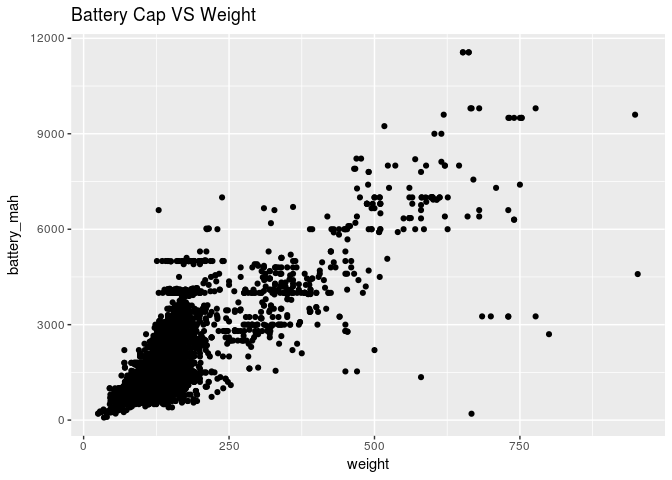

```r
mod = mobile[c('weight','battery_mah')] %>% na.omit()
p = ggplot(data = mod, aes(x=weight, y = battery_mah))
p + geom_point() + ggtitle('Battery Cap VS Weight')
```

```r
correlation = cor(mod$battery_mah, mod$weight)
print(correlation)
```

```
## [1] 0.8086273
```

۹. قیمت پرچمداران یک برند خاص مثلا سامسونگ را بیابید و نمودار قیمت زمان و نام مدل را رسم نمایید.

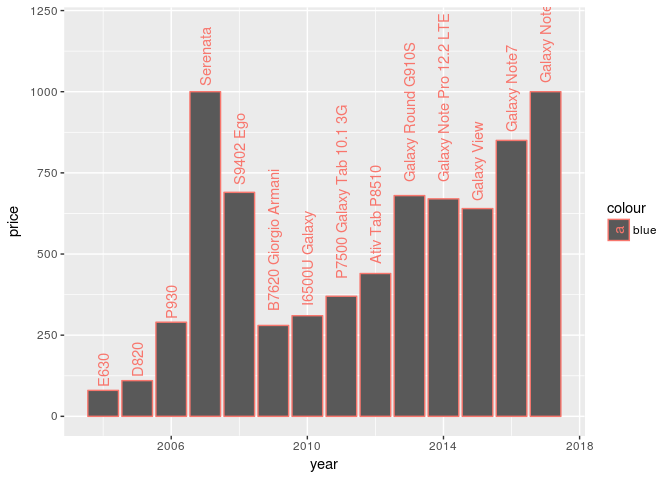

```r
# part 9
brand = 'Samsung'
mod = mobile[c('device','company','price','year')] %>% na.omit()
mod = mod[which(mod$company == brand),]
mod %>% group_by(year) %>% slice(which.max(price)) -> mod
p = ggplot(data=mod, aes(x=year, y = price,color='blue'))
p + geom_bar(stat = 'identity') + geom_text(aes(label = device), angle = 90, hjust = -0.1) + scale_y_continuous(limits = c(0,1200))
```

۱۰. سه نمودار جالب رسم کنید و توضیح دهید چرا از نظر شما جالب است؟

در زیر نمودار نسبت کیفیت دوربین سلفی به دوربین عقب گوشی ها نسبت به زمان کشیده شده است

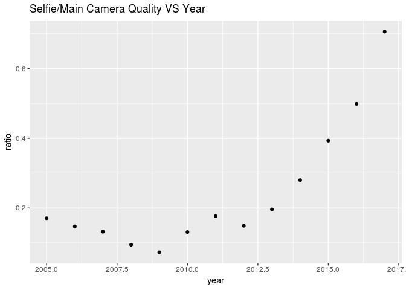

```r
mobile %>% select(company, device, year, cam_px, sel_px) %>% na.omit() %>% group_by(year) %>% summarise(ratio = mean(sel_px) / mean(cam_px)) -> mod
p = ggplot(data = mod, aes(x = year, y= ratio))
p + geom_point() + ggtitle('Selfie/Main Camera Quality VS Year')
```

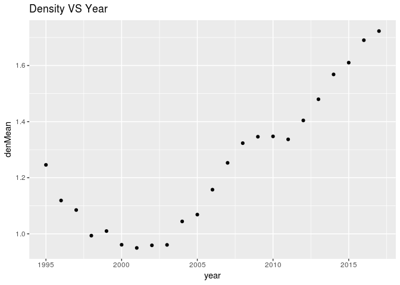

```r
mod = mobile[c('year','dim_length','dim_thickness','dim_breadth','weight')] %>% na.omit()
mod = mod[which(mod$dim_length * mod$dim_breadth * mod$dim_thickness != 0), ]
mod$density = mod$weight/(mod$dim_length * mod$dim_breadth * mod$dim_thickness/1000)
mod %>%  group_by(year) %>% summarise(denMean = mean(density)) -> mod
p = ggplot(data = mod, aes(x=year, y = denMean))
p + geom_point() + ggtitle('Density VS Year')
```

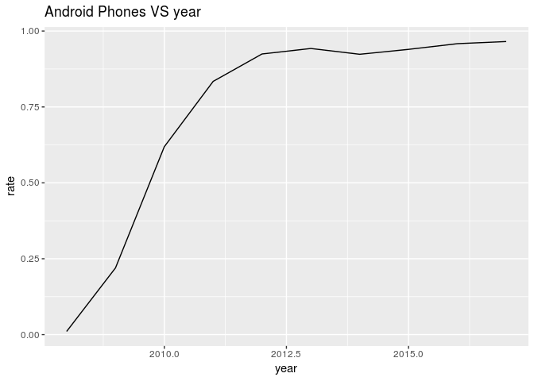

```r
mobile %>% select(os_type, year) %>% na.omit() %>% slice(which(os_type == 'Android')) %>% group_by(year) %>% summarise(count = n())-> mod1
mobile %>% select(os_type, year) %>% na.omit() %>% group_by(year) %>% summarise(count = n()) %>% slice(9:18) -> mod2
mod1$rate = mod1$count / mod2$count
p = ggplot(data = mod1, aes(x= year, y = rate))
p + geom_line() + ggtitle('Android Phones VS year')
```